# Benn.5-24

```r
library(tidyverse)
```

## 7.3.4 Exercises

**1. Explore the distribution of each of the x, y, and z variables in diamonds. What do you learn? Think about a diamond and how you might decide which dimension is the length, width, and depth.**

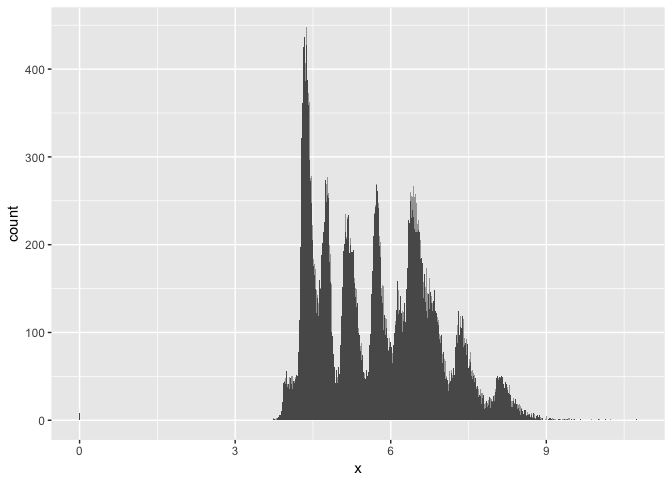

```r
diamonds %>%
  ggplot(mapping = aes(x = x)) + geom_histogram(binwidth = .01)
```

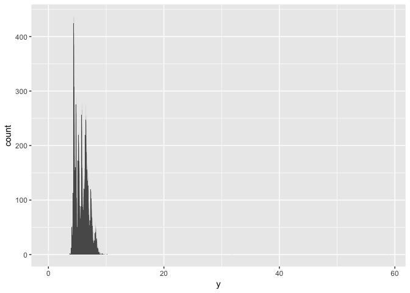

```r
diamonds %>%
  ggplot(mapping = aes(x = y)) + geom_histogram(binwidth = .01)
```

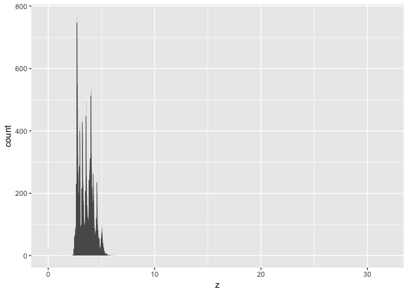

```r
diamonds %>%
  ggplot(mapping = aes(x = z)) + geom_histogram(binwidth = .01)
```

Both Y and Z have some significant outliers.

```r
trimmed <- diamonds %>%
  filter(z < 20 & y < 20)
```

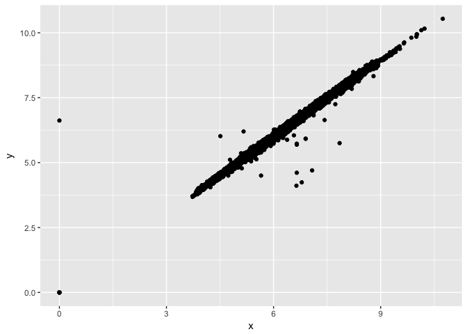

```r
trimmed %>%
  ggplot(aes(x = x, y = y)) + geom_point()
```

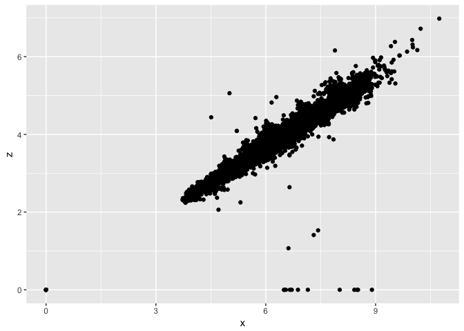

```r
trimmed %>%
  ggplot(aes(x = x, y = z)) + geom_point()
```

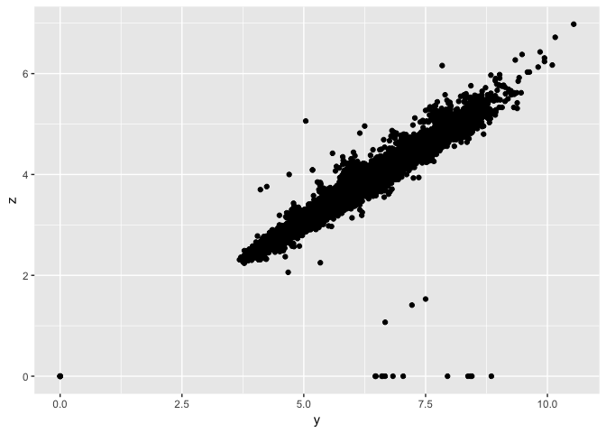

```r
trimmed %>%
  ggplot(aes(x = y, y = z)) + geom_point()
```

Since diamonds are usually circular or square, the length and width would likely be equal in most cases. Looking at the scatterplots, it seems like x and y are well correlated, so they are likely width and length, while z is the depth.

**2. Explore the distribution of price. Do you discover anything unusual or surprising? (Hint: Carefully think about the binwidth and make sure you try a wide range of values.)**

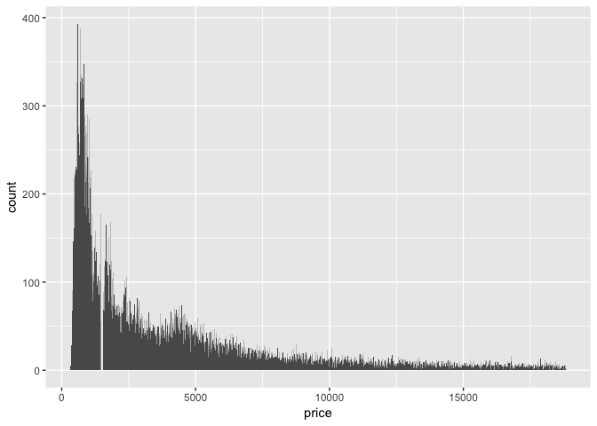

```r
diamonds %>%
  ggplot(mapping = aes(x = price)) + geom_histogram(binwidth = 10)
```

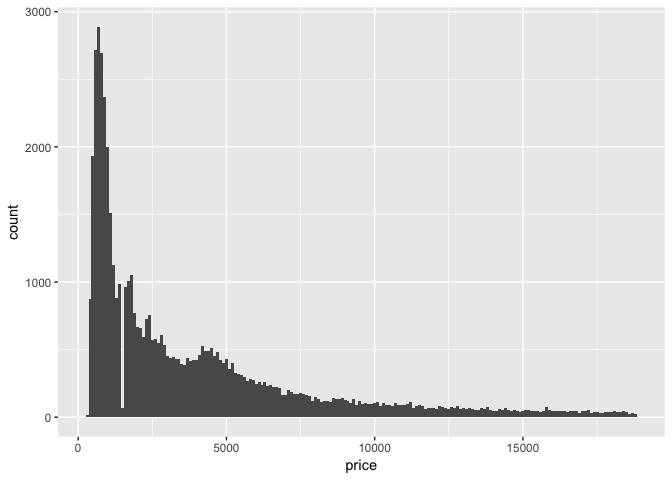

```r
diamonds %>%
  ggplot(mapping = aes(x = price)) + geom_histogram(binwidth = 100)
```

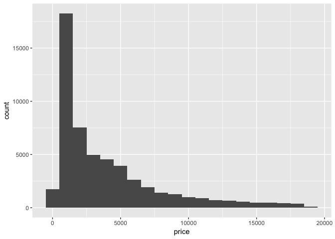

```r
diamonds %>%
  ggplot(mapping = aes(x = price)) + geom_histogram(binwidth = 1000)
```

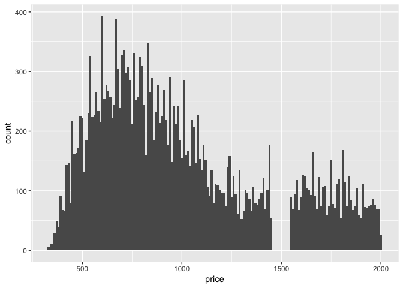

```r
cheap <- diamonds %>%
  filter(price < 2000)
  ggplot(data = cheap, mapping = aes(x = price)) + geom_histogram(binwidth = 10)
```

There’s a gap at $1500 - perhaps a marketing thing?

**3. How many diamonds are 0.99 carat? How many are 1 carat? What do you think is the cause of the difference?**

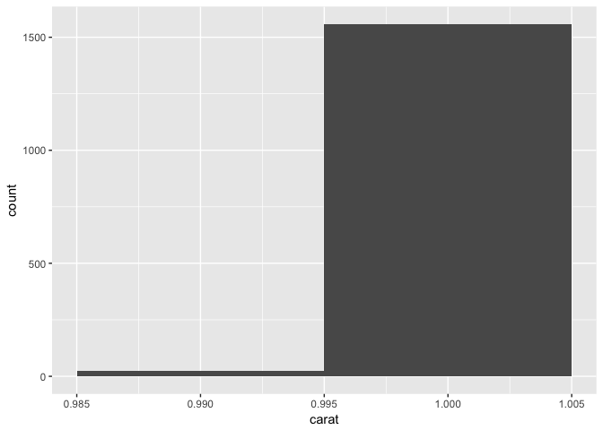

```r
counts <- diamonds
  counts%>%
  filter(carat == 0.99 | carat == 1.00) %>%
  ggplot(mapping = aes(x=carat)) + geom_histogram(binwidth = .01)
```

There are far more 1 carat diamonds - probably a marketing thing. Presumably they try to avoid making diamonds that are close but not quite 1 carat.

**4. Compare and contrast coord_cartesian() vs xlim() or ylim() when zooming in on a histogram. What happens if you leave binwidth unset? What happens if you try and zoom so only half a bar shows?**

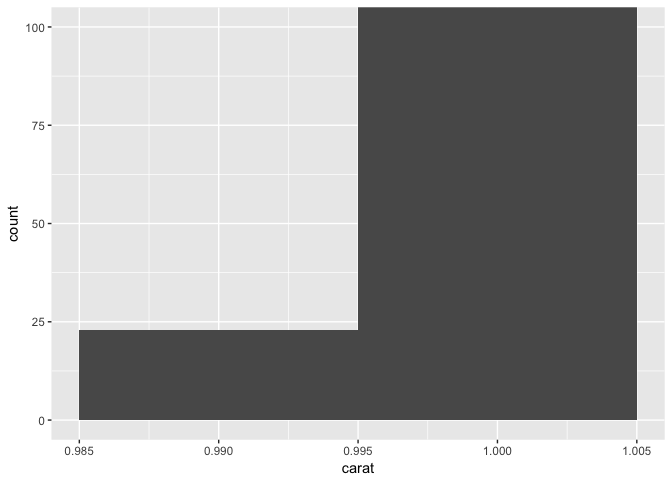

```r
counts <- diamonds
  counts%>%
  filter(carat == 0.99 | carat == 1.00) %>%
  ggplot(mapping = aes(x=carat)) + geom_histogram(binwidth = .01) +
  coord_cartesian(ylim = c(0, 100))
```

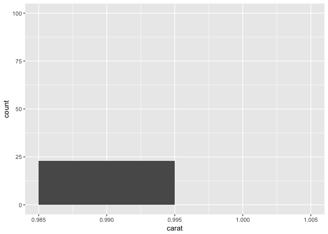

```r
counts <- diamonds
  counts%>%
  filter(carat == 0.99 | carat == 1.00) %>%
  ggplot(mapping = aes(x=carat)) + geom_histogram(binwidth = .01) +
  ylim(0, 100)
```

using ylim drops bars that go above the limit!

## 7.4.1

**1. What happens to missing values in a histogram? What happens to missing values in a bar chart? Why is there a difference?**

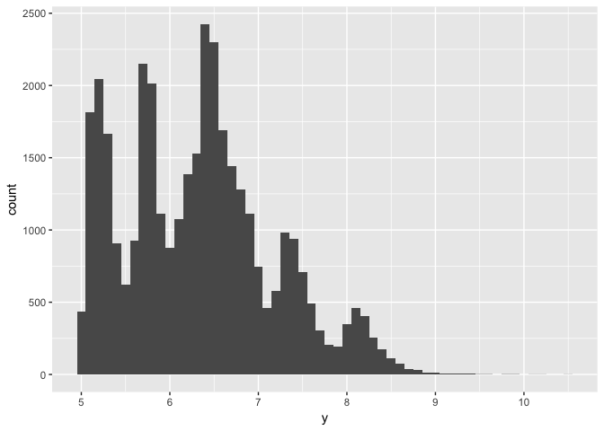

```r
diamonds2 <- diamonds
  diamonds2 %>%
  mutate(y = ifelse(y < 5 | y > 20, NA, y)) %>%
  ggplot(mapping = aes(x= y)) + geom_histogram(binwidth = .1)
```

In histogram, missing values are removed.

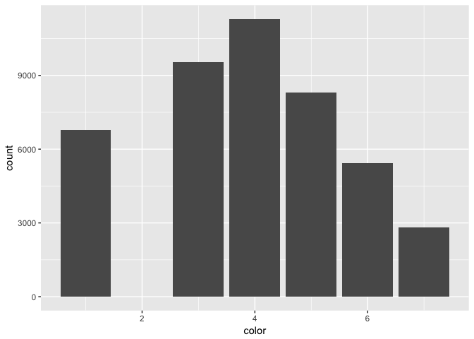

```r
diamonds3 <- diamonds
  diamonds3 %>%
  mutate(color = ifelse(color == "E", NA, color)) %>%
  ggplot(mapping = aes(x= color)) + geom_bar()
```

In barcharts, the values are removed, but it also messes up the axis labels.

**2. What does Na.rm do in mean() and sum()?**

Na.rm removes NAs and allows the calculation to proceed.

## 7.5.1.1 Exercises

**1. Use what you’ve learned to improve the visualisation of the departure times of cancelled vs. non-cancelled flights.**

```r
library(nycflights13)
```

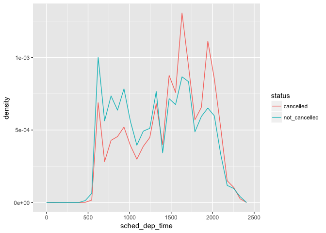

```r
flights %>%
  mutate(status =  ifelse(is.na(arr_delay),"cancelled","not_cancelled")) %>%
  select(sched_dep_time, arr_delay, status) %>%
  ggplot(aes(x = sched_dep_time, y = ..density.., color = status)) + geom_freqpoly()
```

**2. What variable in the diamonds dataset is most important for predicting the price of a diamond? How is that variable correlated with cut? Why does the combination of those two relationships lead to lower quality diamonds being more expensive?**

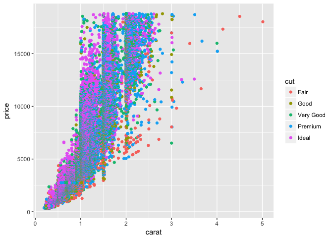

```r
diamonds %>%
  ggplot(aes(x = carat, y = price, color = cut)) + geom_point()
```

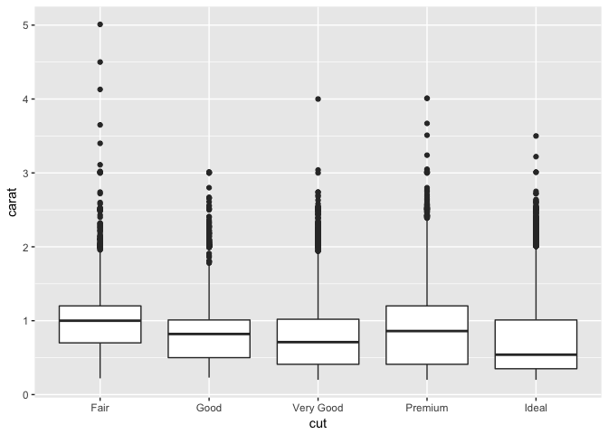

```r
diamonds %>%
  ggplot(aes(x = cut, y = carat)) + geom_boxplot()
```

The largest diamonds tend to be of lower quality cuts.

**3. Install the ggstance package, and create a horizontal boxplot. How does this compare to using coord_flip()?**

```r
library(ggstance)
```

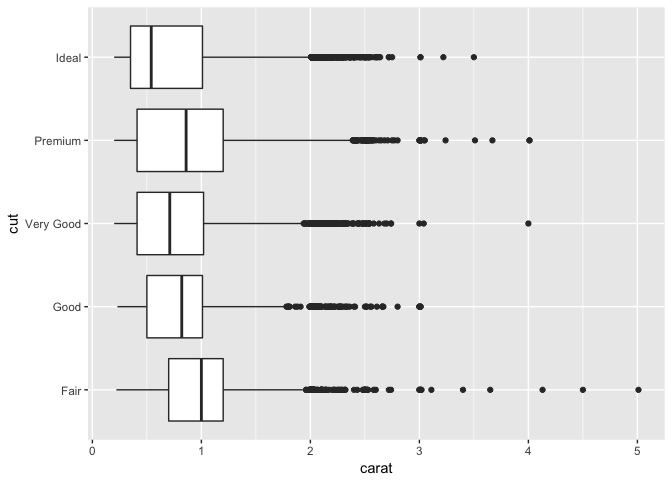

```r
diamonds %>%
  ggplot(aes(x = cut, y = carat)) + geom_boxplot() + coord_flip()
```

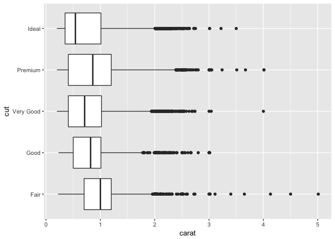

```r
diamonds %>%
  ggplot(mapping = aes(x = carat, y = cut)) + geom_boxploth()
```

They seem to be the same - the boxploth command is slightly simpler.

**4. One problem with boxplots is that they were developed in an era of much smaller datasets and tend to display a prohibitively large number of “outlying values”. One approach to remedy this problem is the letter value plot. Install the lvplot package, and try using geom_lv() to display the distribution of price vs cut. What do you learn? How do you interpret the plots?**

ggproto error

**5. Compare and contrast geom_violin() with a facetted geom_histogram(), or a coloured geom_freqpoly(). What are the pros and cons of each method?**

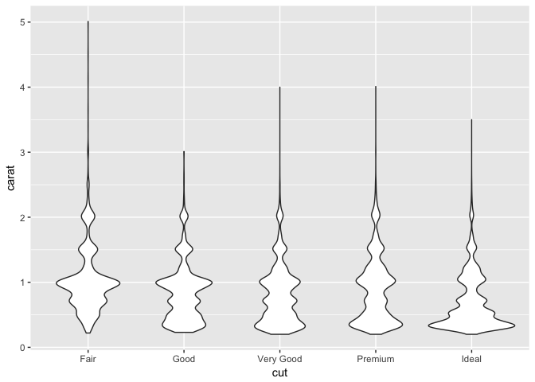

```r
diamonds %>%
  ggplot(aes(x = cut, y = carat)) + geom_violin()
```

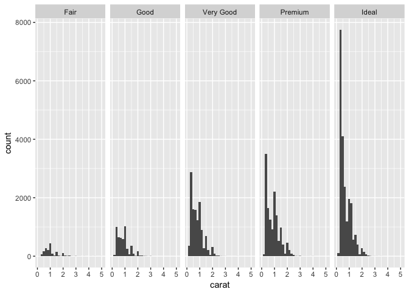

```r
diamonds %>%
  ggplot(aes(x = carat)) + geom_histogram() + facet_grid(.~cut)
```

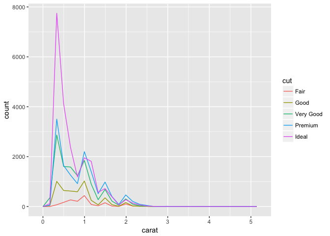

```r
diamonds %>%
  ggplot(aes(x = carat, color = cut)) + geom_freqpoly()
```

The violin and faceted plots are both nice - they let you see the distribution. The faceted plot give you a better idea of the relative abundance though.